# Basic Point Classification Techniques

Eric Bridgeford

January 2, 2017

```r
suppressMessages(require(gridExtra))
suppressMessages(require(ggplot2))
suppressMessages(require(lolR))
suppressMessages(require(latex2exp))
suppressMessages(require(MASS))
suppressMessages(require(grid))
```

# Introduction

## Me

- Name: Eric Bridgeford
- What I do: computational neuroscience research with Dr. Josh Vogelstein (yes, he is the guy you see walking around barefoot with dreadlocks)
- My background: BME/CS major with math minor
  - I put incredibly low effort freshman and sophomore year; don’t be like me; your classes may seem useless now but surprise: they won’t be
  - I may be biased but if you are going to slack don’t do it in a math or programming class; it will bite you in the a$$ later on
- Interesting Aside: I took this class my freshman year 4 years ago (it was my first programming class, and I struggled fairly epically)
  - did research over the summer and finally programming started to click; declared CS major the following year

## You

Tell me about your background?

How many of you have taken a statistics class?

How many of you are familiar with statistics?

How many of you are vaguely interested in statistics?

How many of you are pre-med?

Do any of you want to do something like research at a pharmaceutical company or in academics?

## What we are going to cover

Basic application of mathematics, statistics, and programming.

I guess you could call it Machine Learning; I’m not a big fan of that name because it’s such a general topic area, but this is pretty much in that topic area.

# Basic Point Classification

## Background

### What is a normal distribution and why should we care?

- one of the most commonly used probability distributions to represent data
- also called the “Bell Curve”

### Normal Distribution Probability Density Function in 1 Dimension

$$\begin{align*}
f_X &= \mathcal{N}\left(\mu, \sigma^2\right) \\
f_X\left(x; \mu, \sigma^2\right) &= \frac{1}{\sqrt{2 \pi \sigma^2}} e^{-\frac{(x - \mu)^2}{2\sigma^2}}
\end{align*}$$

- $\mu$ is the mean of the data. the “average value” the data can take
- $\sigma$ is the variance of the data. Kind of like the “width” of the possible values that the data can take

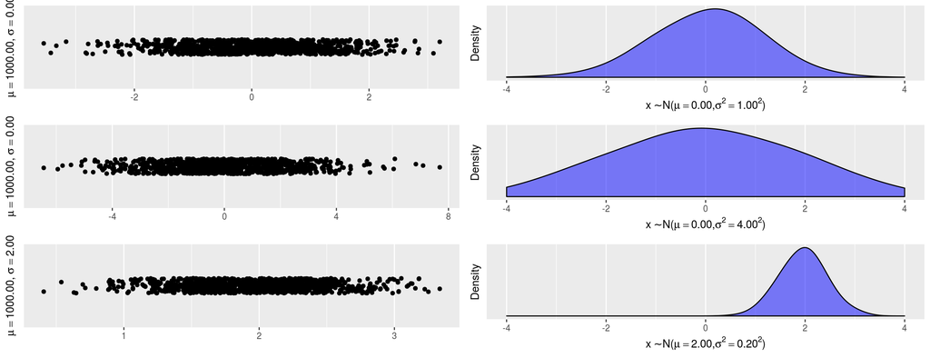

```r
oned.plot <- function(n, mu, var) {
  x = rnorm(n, mean=mu, sd=sqrt(var))
  data <- data.frame(x=x)
  cent <- ggplot(data, aes(x=x, y=0)) +
    geom_jitter(height=0.2) +
    ylim(c(-1, 1)) +
    ylab(TeX(sprintf("$\\mu = %.2f$, $\\sigma = %.2f$", n, mu, var))) +
    xlab("") +
    scale_y_continuous(labels=c(), breaks=c(), limits=c(-1, 1)) +
    theme()
  bottom <- ggplot(data, aes(x)) +
    geom_density(fill='blue', alpha=0.5, adjust=2) +
    xlim(c(-4, 4)) +
    xlab(TeX(sprintf("$x \\sim N(\\mu = %.2f, \\sigma^2 = %.2f^2)$", mu, var))) +
    scale_y_continuous(labels=c(), breaks=c()) +
    ylab("Density")
  return(arrangeGrob(cent, bottom, ncol=2, widths=c(.5, .5)))
}
n <- 1000
mu <- 0; var <- 1
normal <- oned.plot(n, mu, var)

mu <- 0; var <- 4
wide <- oned.plot(n, mu, var)
mu <- 2; var <- 0.2
narrow <- oned.plot(n, mu, var)

grid.arrange(normal, wide, narrow, ncol=1)
```

As you can see above, $\mu$ is controlling the center of the points, and $\sigma$ is controlling the width of the range the points can occupy.

### Normal Distribution PDF in Multiple Dimensions

$$\begin{align*}
f_X &= \mathcal{N}\left(\mu, \Sigma\right) \\
f_X\left(x; \mu, \Sigma\right) &= \frac{1}{\sqrt{det(2\pi \Sigma)}} e^{-\frac{1}{2}(x - \mu)^T \Sigma^{-1}(x - \mu)}
\end{align*}$$

Looks more complex, but it’s really not. Let’s use a similar visualization to before to visualize a normal distribution with spherical covariance structuring in 2 dimensions:

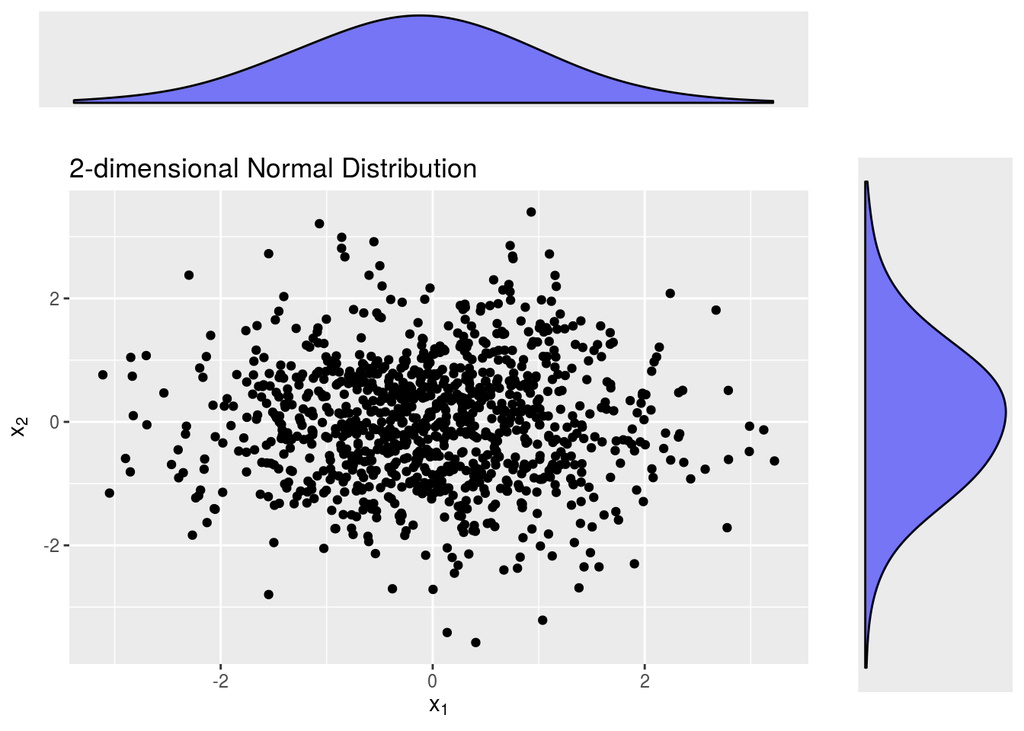

```r
twod.plot <- function(n, mu, cov) {
  x = MASS::mvrnorm(n, mu=mu, Sigma=cov)
  data <- data.frame(x1=x[, 1], x2=x[, 2])
  cent <- ggplot(data, aes(x=x1, y=x2)) +
    geom_point() +
    ylab(TeX("$x_2$")) +
    xlab(TeX("$x_1$")) +
    ggtitle("2-dimensional Normal Distribution")
  right <- ggplot(data, aes(x2)) +
    geom_density(fill='blue', alpha=0.5, adjust=2) +
    xlab("") +
    ylab("") +
    scale_x_continuous(labels=c(), breaks=c()) +
    scale_y_continuous(labels=c(), breaks=c()) +
    coord_flip()
  top <- ggplot(data, aes(x1)) +
    geom_density(fill='blue', alpha=0.5, adjust=2) +
    xlab("") +
    ylab("") +
    scale_x_continuous(labels=c(), breaks=c()) +
    scale_y_continuous(labels=c(), breaks=c())
  empty <- ggplot()+geom_point(aes(1,1), colour="white")+
         theme(axis.ticks=element_blank(),
               panel.background=element_blank(),
               axis.text.x=element_blank(), axis.text.y=element_blank(),
               axis.title.x=element_blank(), axis.title.y=element_blank())
  return(arrangeGrob(top, empty, cent, right, ncol=2, nrow=2, widths=c(4, 1), heights=c(1, 4)))
}
n <- 1000
d <- 2
mu <- array(0, dim=c(d, 1))
cov <- diag(d)
grid.arrange(twod.plot(n, mu, cov))
```

As you can see above, this is incredibly similar to our 1-dimensional setup of the normal distribution, except now we have 2 dimensions instead of 1 being normally distributed. There are some funky ways that the different dimensions have higher level interactions called covariances, but this idea can generally be extended arbitrarily to $d$-dimensions.

## Problem Formulation

### Data Setup

Now that we have some intuition about how the normal distribution works, we are ready to formulate a problem mathematically:

$$\begin{align*}
(X, Y) \sim F_{XY} \\
X: \Omega \rightarrow \mathbb{R}^d \\
Y: \Omega \rightarrow \{0, 1\}
\end{align*}$$

The above notation seems pretty esoteric but all it says is as follows:

- $X$ and $Y$ are related by some joint distribution $F_{XY}$: there is some way to generalize an interaction between $X$ and $Y$
- The random variable $X = \{x_i\}_{i=1}^n$ has samples $x_i$ that are $d$-dimensional and real ($\mathbb{R}^d$). This is referred to as our data.
- The random variable $Y=\{y_i\}_{i=1}^n$ has samples $y_i$ that are either a $0$ or a $1$. These are referred to as “labels” for our data.

Using our notation developed above, we will have the following:

$$\begin{align*}
X | Y = 0 \sim f_0 &= \mathcal{N}\left(\mu_0, \Sigma_0\right) \\
X | Y = 1 \sim f_1 &= \mathcal{N}\left(\mu_1, \Sigma_1\right)
\end{align*}$$

$f_0$ and $f_1$ are called our marginal distirbutions. They give the probability distribution of a subset of $X$ conditioned on the value of $Y$, as the probability distribution of $X$ is different depending on which label it has.

Note that this setup leaves open the possibility for $f_0$ and $f_1$ to be pretty much anything, which gives us no insight into how to develop our model.

$$\begin{align*}
\mathbb{P}\left(y_i = j\right) = \pi_j
\end{align*}$$

This just means that we see $y_i$ taking class label $j$ with probability $\pi_j$ for our labels $j$ which can be 0 or 1.

Clearly, $0$ and $1$ are the only values that $y_i$ can take. If we think of $y_i$ as a coin flip, there are only 2 outcomes. The probability of getting either a heads or a tails is clearly 1, just like the probability of both of these events happening:

$$\begin{align*}
\sum_{j \in \{0, 1\}} \pi_j = 1
\end{align*}$$

### Goal

Figure out when a particular $x_i$ would be a $1$, and when it would be a $0$.

Formally, Given:

$$\begin{align*}
g(X)&: X \rightarrow Y \\
L(g(X); Y) &= \frac{1}{n}\sum_{i = 1:n}\mathbb{I}\left\{g(x_i) \neq y_i\right\}
\end{align*}$$

- $g(X)$ is a function that maps each point to a value in $Y$. That means for each sample $x_i$, we have an associated label $y_i$. This is our “classification function”.
- $L(g(X); Y)$ is just a function that counts the number of times we incorrectly guess the labels for each $x_i$. $\mathbb{I}\{\cdot\}$ is a function that returns $1$ if $\cdot$ is true, and $0$ if $\cdot$ is false. This loss function can be called our “classification error”. We are counting the number of times are classification function is wrong.

Identify:

$$\begin{align*}
g^*(X) = \textrm{argmin}_{g(x)} L(g(X))
\end{align*}$$

Figure out the best possible function $g(X)$, above called $g^*(X)$, that minimizes this notion of “classification error”. This is the best possible classifier for our classification setup.

### Constraining our problem

This problem is hard; there are entire fields dedicated to how to solve it best. We can simplify it by assuming some basic things:

$$\begin{align*}
\Sigma_0 = \Sigma_1 = I_d
\end{align*}$$

Here, this means that we are assuming that our marginal distributions $f_0$ and $f_1$ have the same notion of “width” that we developed before, and there are no “high-level” associations between the “widths”. This is the exact same setup as our $2$-dimensional example we developed above.

$$\begin{align*}
\pi_0 = \pi_1 = 0.5
\end{align*}$$

This means that on average, we aren’t really going to see more of one class than another.

Finally, we will assume that:

$$\begin{align*}
\mu_0 \neq \mu_1
\end{align*}$$

That is, the means of our two distributions are non-equal, and capture all of the difference between class $0$ and class $1$.

Let’s take a look at what this data may look like in a $2$-dimensional case:

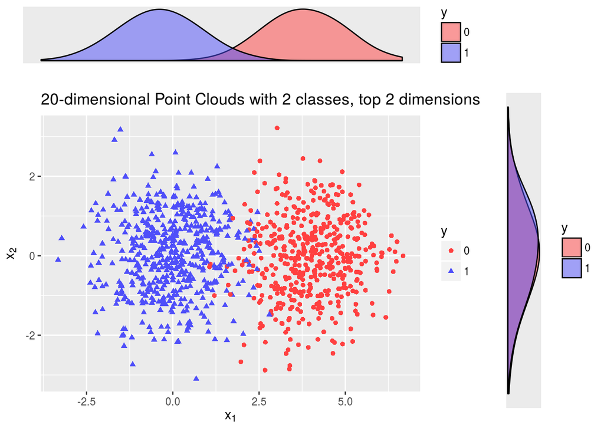

```r
plot.center <- function(data, cols, sizes, title) {
  return(ggplot(data, aes(x=x1, y=x2, color=y, shape=y, size=y)) +
    geom_point() +
    ylab(TeX("$x_2$")) +
    xlab(TeX("$x_1$")) +
    scale_color_manual(values=cols) +
    #scale_shape_manual(values=shapes) +
    scale_size_manual(values=sizes) +
    ggtitle(title))
}
cols = c("#ff4040", "#4f4ff9", "#09ba09")
name.vec <- c("0", "1", "center")
names(cols) <- name.vec
shapes = c(16, 16, "star")
names(shapes) <- name.vec
sizes = c(1.5, 1.5, 5)
names(sizes) <- name.vec
twod.plot <- function(data, cols, shapes, sizes) {
  data$y <- factor(data$y)
  cent <- plot.center(data, cols, sizes, "20-dimensional Point Clouds with 2 classes, top 2 dimensions")
  right <- ggplot(base::subset(data, y != "center"), aes(x2, fill=y)) +
    geom_density(alpha=0.5, adjust=2) +
    xlab("") +
    ylab("") +
    scale_fill_manual(values=cols) +
    scale_x_continuous(labels=c(), breaks=c()) +
    scale_y_continuous(labels=c(), breaks=c()) +
    coord_flip()
  top <- ggplot(base::subset(data, y != "center"), aes(x1, fill=y)) +
    geom_density(alpha=0.5, adjust=2) +
    xlab("") +
    ylab("") +
    scale_fill_manual(values=cols) +
    scale_x_continuous(labels=c(), breaks=c()) +
    scale_y_continuous(labels=c(), breaks=c())
  empty <- ggplot()+geom_point(aes(1,1), colour="white")+
         theme(axis.ticks=element_blank(),
               panel.background=element_blank(),
               axis.text.x=element_blank(), axis.text.y=element_blank(),
               axis.title.x=element_blank(), axis.title.y=element_blank())
  return(arrangeGrob(top, empty, cent, right, ncol=2, nrow=2, widths=c(4, 1), heights=c(1, 4)))
}

n <- 1000; d <- 20
sim <- lol.sims.mean_diff(n=n, d=d, md=2)
sim$Y <- sim$Y - 1  # to make it 0, 1 instead of 1, 2
data <- data.frame(x1=sim$X[,1], x2=sim$X[,2], y=sim$Y)
grid.arrange(twod.plot(data, cols[1:2], shapes[1:2], sizes[1:2]))
```

### A Simple Classifier

Looking at this data, it’s pretty clear that the biggest difference in the points is just the mean separation, as we previously discussed.

If we were to have some notion of where the center of each “cluster” of points were, we could probably do a pretty good job figuring out which class a point belonged to just by looking at which center it is closest to.

#### Model

We will use the following estimate of the mean:

$$\begin{align*}
\hat{\mu}_j = \frac{1}{|\{i: y_i = j\}|}\sum_{i: y_i = j} x_i
\end{align*}$$

What are we doing above?

Just taking the average of the points with a label $j$ to define the estimate of the mean $\hat{\mu}_j$ for cluster $j$.

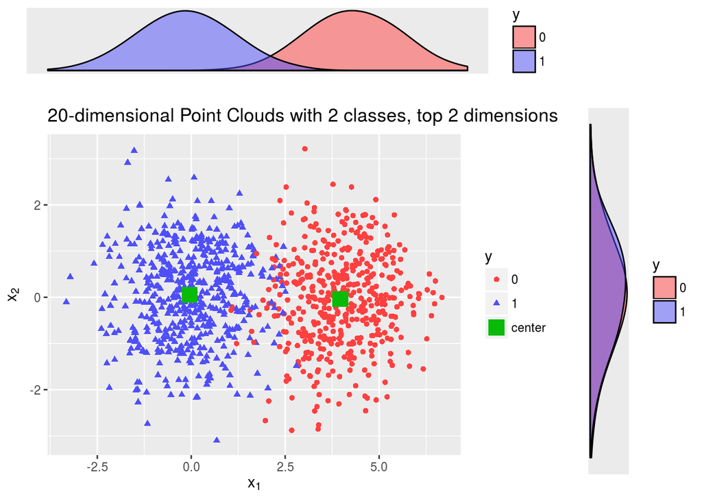

```r
model <- lol.classify.nearestCentroid(sim$X, sim$Y)
data <- rbind(data, data.frame(x1=model$centroids[, 1], x2=model$centroids[, 2], y="center"))
grid.arrange(twod.plot(data, cols, shapes, sizes))
```

#### Classification (Prediction) Function

As we said, let’s just assign each point to the center that it is closest to using the euclidian distance:

$$\begin{align*}
\hat{y}_i = g(x_i) = \textrm{argmin}_{j \in \{0, 1\}} ||x_i - \mu_j||
\end{align*}$$

Where $||\cdot||$ is the euclidian distance you are all probably familiar with:

$$\begin{align*}
||a|| = \sqrt{a_1^2 + a_2^2 + ... a_d^2}
\end{align*}$$

that gives us a notion of a “distance” to a particular center.

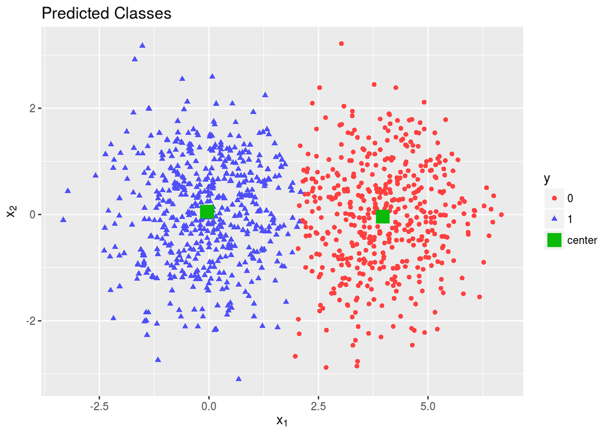

```r
Yhat <- predict(model, sim$X)
datahat <- data.frame(x1=sim$X[,1], x2=sim$X[,2], y=Yhat)
datahat <- rbind(datahat, data.frame(x1=model$centroids[, 1], x2=model$centroids[, 2], y="center"))
grid.arrange(plot.center(datahat, cols, sizes, "Predicted Classes"))
```

As we can see in the above example, our predictions are pretty good. Our points are assigned to the closest center. Comparing with the original data:

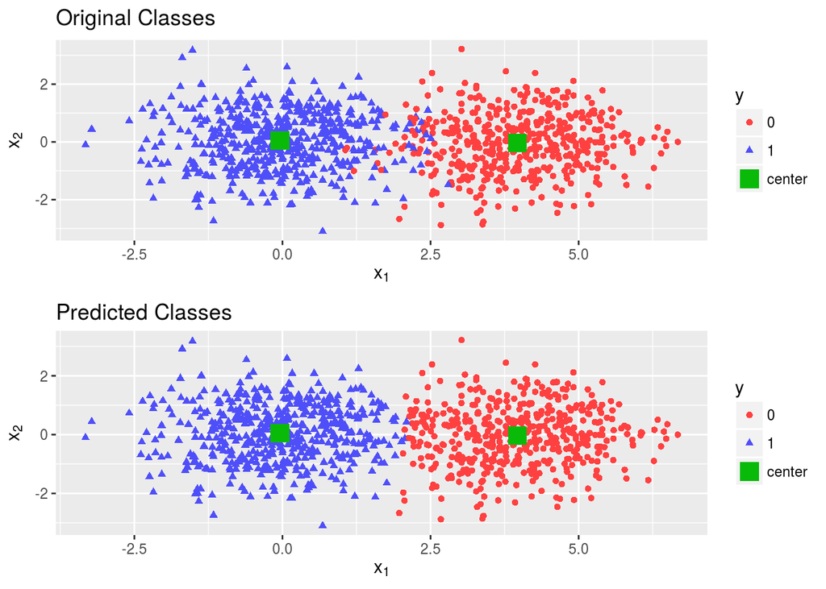

```r
grid.arrange(plot.center(data, cols, sizes, "Original Classes"),
             plot.center(datahat, cols, sizes, "Predicted Classes"))
```

Where our “classification error” is:

```r
print(sum(Yhat != sim$Y)/length(sim$Y))
```

```
## [1] 0.027
```

## Downsides

Things get much more complex than this. We made several assumptions, mainly:

- $\pi_0 = \pi_1 = 0.5$, meaning that we see each class with fairly equal probability
  - this is rarely the case in real data; often we will have completely biased proportions where we see more of one class than another.
- $\Sigma_0 = \Sigma_1 = I_d$, meaning that each class has similar covariance matrices, and we assume there is no covariance or higher order relationships between our distributions
- many other things that make our simple model naive in many situations

## Contact Information

Me: ericwb95@gmail.com Jovo (Josh Vogelstein) my boss: jovo@jhu.edu

We have openings for research this semester; contact us for details!

Thanks!